# Teste T (de Student) para duas amostras independentes

## Backgorund da análise

Uma das perguntas mais comum em estatística é saber se há diferença entre as médias de dois grupos ou tratamentos. Para responder esta pergunta, William Sealy Gosset, químico da cervejaria Guinness, em 1908 desenvolveu o Teste T que é uma estátistica que segue uma distribuição t de Student para rejeitar ou não uma hipótese nula de médias iguais entre os grupos.

> $$t = \frac{(\bar{X}_1 - \bar{X}_2)}{\sqrt{\frac{2S^2_p}{n}}}$$

Onde:

- $\bar{X}$<sub>1</sub> - $\bar{X}$<sub>2</sub> = diferença entre as médias das duas amostras,
- S<sup>2</sup><sub>p</sub> = desvio padrão das amostras,
- *n* = tamanho das amostras.

#### Premissas do Teste t :

> - As amostras devem ser independentes;
> - As unidades amostrais são selecionadas aleatoriamente;
> - Distribuição normal (gaussiana) dos resíduos. **Observação:** Zar (2010, p. 136) indica que o Test T é robusto mesmo com moderada violação da normalidade, principalmente se o tamanho amostral for alto.
> - Homogeneidade da variância. **Observação.** Caso as variâncias não sejam homogêneas, isso deve ser informado na linha de comando, pois o denominador da fórmula acima será corrigido.

#### Avaliação das premissas:

> Uma das maneiras de avaliarmos as premissas de normalidade e homogeneidade da variância relacionadas as análises do teste T, Anova e regressões simples e múltiplas é o uso da inspeção gráfica da distribuição dos resíduos (Figura 1). A homegeneidade da variância utiliza um gráfico dos resíduos pelos valores preditos (Figura 1A). A distribuição dos resíduos será homogênea se não observarmos nenhum padrão na distribuição dos pontos (i.e. forma em V, U ou funil). A normalidade dos resíduos utiliza um gráfico de quantis-quantis (QQ-plots). A distribuição dos resíduos será normal se os pontos estiverem próximos a reta (Figure 1B).

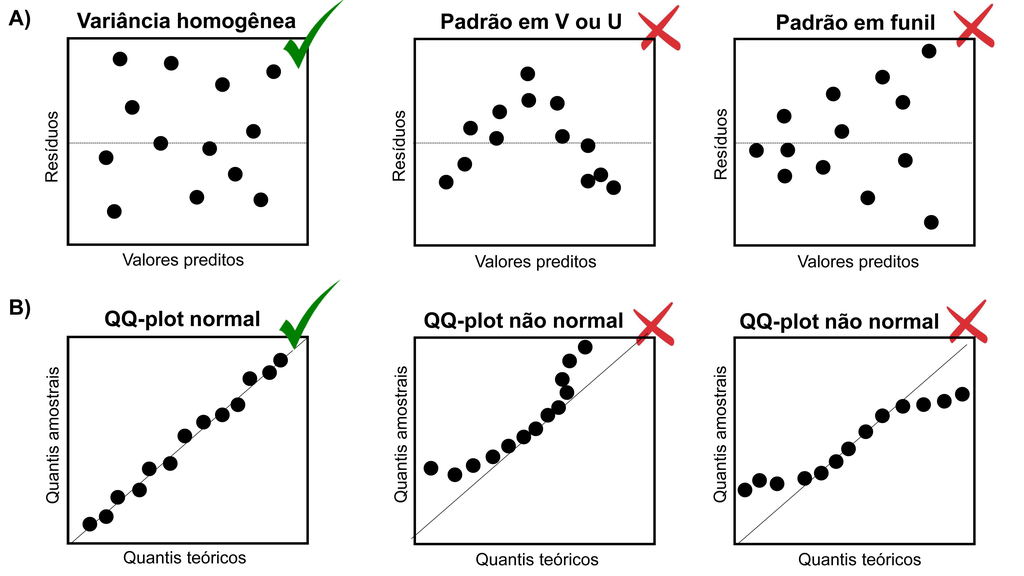

Figura 1. Inspeção gráfica da homegeneidade da variância (A) e normalidade (B) dos resíduos. Símbolo verde indica que os gráficos que os resíduos apresentam distribuição homegênea e normal enquanto símbolos vermelhos indicam que os gráficos que os resíduos violam as premissas do teste

#### Exemplo prático 1 - Teste T para duas amostras com variâncias iguais

##### Explicação dos dados

Neste exemplo avaliaremos o comprimento rostro-cloacal (CRC em milímetros) de machos de *Physalaemus natteri* (Anura:Leptodactylidae) amostrados em diferentes estações do ano com armadilhas de interceptação e queda na região noroeste do estado de São Paulo (da Silva & Rossa-Feres 2010).

**Pergunta:**

> O CRC dos machos de *P. nattereri* é maior na estação chuvosa do que na estação seca?

**Predições**

> O CRC dos machos será maior na estação chuvosa porque há uma vantangem seletiva para os indivíduos maiores durante a atividade reprodutiva.

**Variáveis**

- Variáveis preditoras
  - Dataframe com os indivíduos (unidade amostral) nas linhas e CRC (mm - variável resposta contínua) e estação (variável preditora categórica) como colunas.

**Checklist**

- Verificar se o seu dataframe está com as unidades amostrais nas linhas e variáveis preditores nas colunas

### Análise

Calculo do Teste T para duas amostras independentes com variâncias iguais

```r
## IMPORTANDO OS DADOS
#************************
library(ecodados)
CRC_PN_macho <- teste_t_var_igual
# verificar se o dataframe foi lido corretamente e se não há erros
head(CRC_PN_macho) # mostra as seis primeiras linhas da planilha
```

```
##    CRC Estacao
## 1 3.82 Chuvosa
## 2 3.57 Chuvosa
## 3 3.67 Chuvosa
## 4 3.72 Chuvosa
## 5 3.75 Chuvosa
## 6 3.83 Chuvosa
```

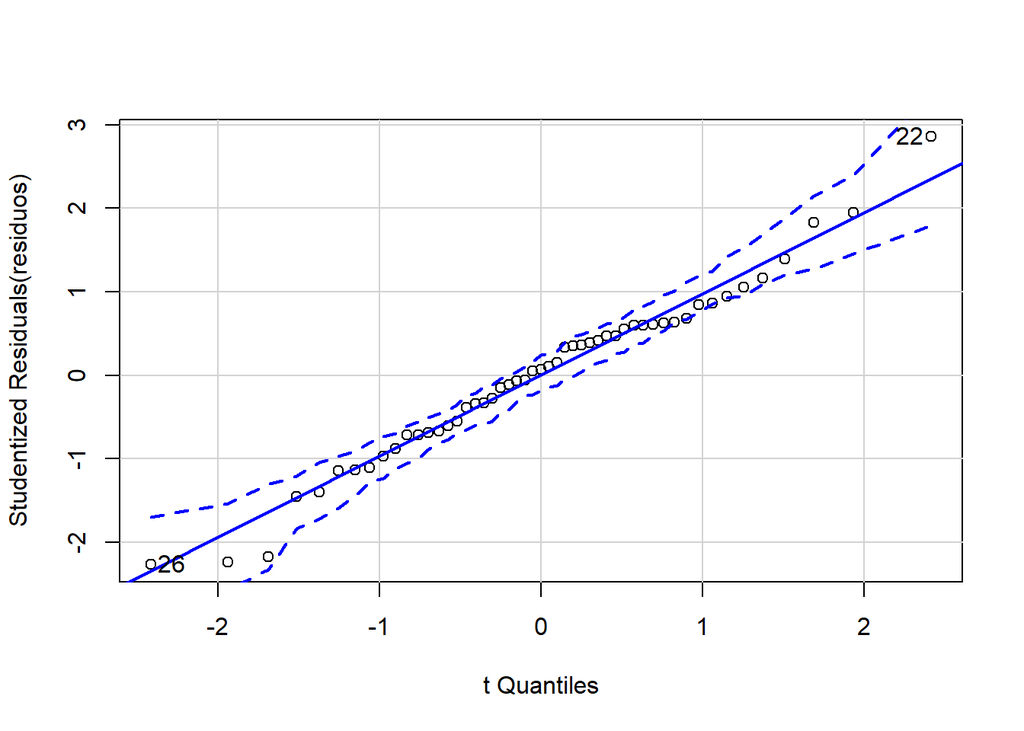

```
## [1] 22 26
```

```r
# TESTE NORMALIDADE
#************************
## Verificando normalidade usando QQ-plot
residuos <- lm(CRC ~ Estacao, data = CRC_PN_macho)
library("car")
qqPlot(residuos)
```

```r
## Outra possibilidade é usar o teste de Shapiro-Wilk para verificar normalidade
## Hipótese nula que a distribuição é normal
## valor de p < 0.05 significa que os dados não apresentam distribuição normal
## valor de p > 0.05 significa que os dados apresentam distribuição normal
shapiro.test (CRC_PN_macho$CRC)
```

```
##
##  Shapiro-Wilk normality test
##
## data:  CRC_PN_macho$CRC
## W = 0.95559, p-value = 0.05417
```

```r
# TESTE DE HOMOGENEIDADE DA VARIÂNCIA
#***************************************
## Hipótese nula que a variância é homogênea
## valor de p < 0.05 significa que os dados não apresentam homogeneidade
## valor de p > 0.05 significa que os dados apresentam homogeneidade
library(car)
leveneTest(CRC ~ Estacao, data = CRC_PN_macho)
```

```
## Levene's Test for Homogeneity of Variance (center = median)
##       Df F value Pr(>F)
## group  1  1.1677 0.2852
##       49
```

Percebam que a distribuição dos resíduos foi normal e homogênea tanto na inspeção gráfica como nos testes de Shapiro e Levene respectivamente. Agora, podemos realizar a análise sabendo que os dados seguem as premissas requeridas pelo test T.

```r
# TESTE T AMOSTRAS INDEPENDENTES E VARIÂNCIAS IGUAIS
#******************************************************888
t.test(CRC ~ Estacao, data = CRC_PN_macho, var.equal = TRUE)
```

```
##
##  Two Sample t-test
##
## data:  CRC by Estacao
## t = 4.1524, df = 49, p-value = 0.000131
## alternative hypothesis: true difference in means is not equal to 0
## 95 percent confidence interval:
##  0.2242132 0.6447619
## sample estimates:
## mean in group Chuvosa    mean in group Seca
##              3.695357              3.260870
```

Visualizar os resultados em gráfico

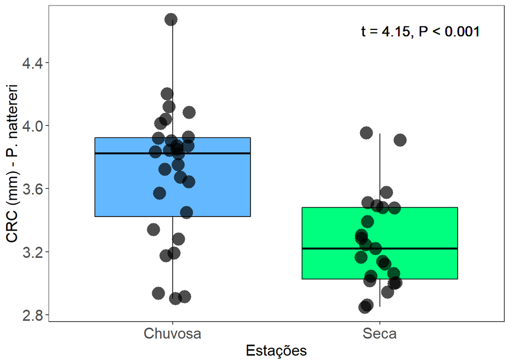

```r
library(ggplot2)
ggplot(data = CRC_PN_macho, aes(x= Estacao, y= CRC, color = Estacao)) +
  labs(x = "Estações", y = "CRC (mm) - P. nattereri", size = 15) +
  geom_boxplot(fill=c("steelblue1", "springgreen1"), color="black", outlier.shape = NA) +
  geom_jitter(shape = 16, position=position_jitter(0.1), cex = 6, alpha = 0.7) +
  scale_color_manual(values = c("black", "black")) +
  geom_text(x = 2.2, y = 4.6, label = "t = 4.15, P < 0.001", color = "black", size = 5) +
  theme_bw() +
  theme(axis.text.y = element_text(size = 15), axis.text.x = element_text(size = 15)) +
  theme(axis.title.y = element_text(size = 15), axis.title.x = element_text(size = 15)) +
  theme(panel.grid.major = element_blank(), panel.grid.minor = element_blank()) +
  theme(legend.position = "none")
```

**Interpretação dos resultados**

Neste exemplo, rejeitamos a hipótese nula que as médias do CRC dos machos entre as estações seca e chuvosa são iguais (t = 4,15, P < 0,001). Os resultados mostram que os machos de *P. nattereri* coletados na estação chuvosa foram em média 0,43mm maiores do que os coletados na estação seca.

#### Exemplo prático 2 - Teste T para duas amostras independentes com variâncias diferentes

##### Explicação dos dados

Neste exemplo, avaliaremos o comprimento rostro-cloacal (CRC - milímetros) de fêmeas de *Leptodactylus podicipinus* amostradas em diferentes estações do ano com armadilhas de interceptação e queda na região noroeste do estado de São Paulo (da Silva & Rossa-Feres 2010). **Observação:** Os dados foram alterados em relação a publicação original para se enquadrarem no exemplo de amostras com variâncias diferentes.

**Pergunta:**

> O CRC das fêmeas de *L. podicipinus* é maior na estação chuvosa do que na estação seca?

**Predições**

> O CRC das fêmeas será maior na estação chuvosa porque há uma vantangem seletiva para os indivíduos maiores durante a atividade reprodutiva.

**Variáveis**

- Variáveis preditoras
  - Dataframe com os indivíduos (unidade amostral) nas linhas e CRC (mm - variável resposta contínua) e estação (variável preditora categórica) como colunas.

**Checklist**

- Verificar se o seu dataframe está com as unidades amostrais nas linhas e variáveis preditores nas colunas

### Análise

Calculo do Teste T para duas amostras com variâncias diferentes

```r
## IMPORTANDO OS DADOS
#*************************
CRC_LP_femea <- read.csv("teste_t_var_diferente.csv", header = T, sep = ";")
head(CRC_LP_femea) # verificar se o dataframe foi lido corretamente
```

```
##    CRC Estacao
## 1 2.72 Chuvosa
## 2 2.10 Chuvosa
## 3 3.42 Chuvosa
## 4 1.50 Chuvosa
## 5 3.90 Chuvosa
## 6 4.00 Chuvosa
```

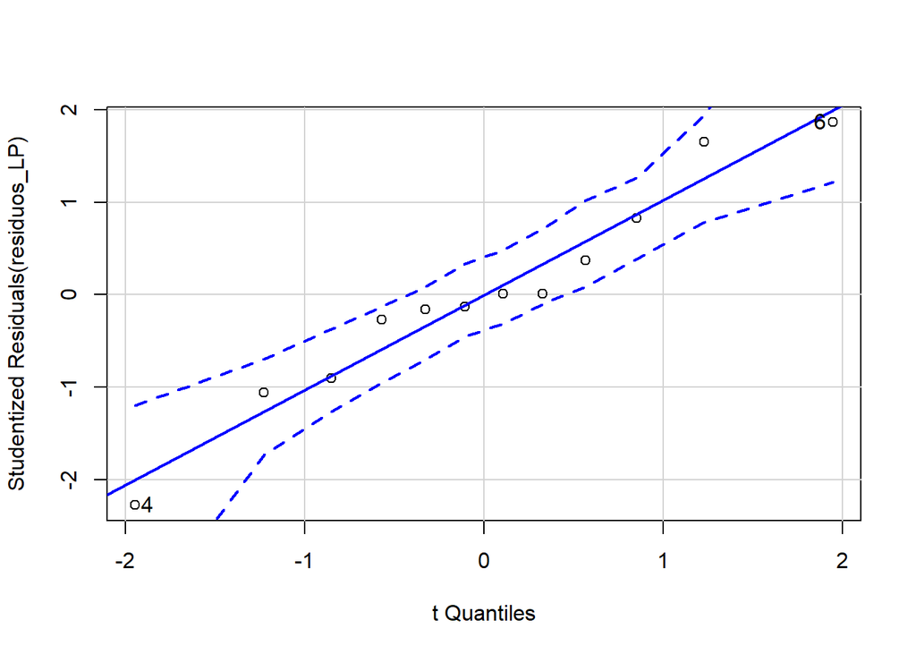

```
## [1] 4 6
```

```r
# TESTE NORMALIDADE
#************************
## Verificando normalidade usando QQ-plot
## Os pontos não podem fugir da reta criando formas como U
residuos_LP <- lm(CRC ~ Estacao, data = CRC_LP_femea)
library("car")
qqPlot(residuos_LP)
```

```r
## Outra possibilidade é usar o teste de Shapiro-Wilk para verificar normalidade
## Hipótese nula que a distribuição é normal
## valor de p < 0.05 significa que os dados não apresentam distribuição normal
## valor de p > 0.05 significa que os dados apresentam distribuição normal
shapiro.test (CRC_LP_femea$CRC)
```

```
##
##  Shapiro-Wilk normality test
##
## data:  CRC_LP_femea$CRC
## W = 0.88195, p-value = 0.09284
```

```r
# TESTE DE HOMOGENEIDADE DA VARIÂNCIA
#***************************************
## Hipótese nula que a variância é homogênea
## valor de p < 0.05 significa que os dados não apresentam homogeneidade
## valor de p > 0.05 significa que os dados apresentam homogeneidade
library(car)
leveneTest(CRC ~ Estacao, data = CRC_LP_femea)
```

```
## Levene's Test for Homogeneity of Variance (center = median)
##       Df F value  Pr(>F)
## group  1  9.8527 0.01053 *
##       10
## ---
## Signif. codes:  0 '***' 0.001 '**' 0.01 '*' 0.05 '.' 0.1 ' ' 1
```

```r
# TESTE T COM AMOSTRAS INDEPENDENTES E VARIÂNCIS DIFERENTES
#***********************************************************
## Com base no teste de Levene, avise na linha de comando que as variâncias
## não são iguais (var.equal = FALSE).
t.test(CRC ~ Estacao, data = CRC_LP_femea, var.equal = FALSE)
```

```
##
##  Welch Two Sample t-test
##
## data:  CRC by Estacao
## t = -1.7633, df = 6.4998, p-value = 0.1245
## alternative hypothesis: true difference in means is not equal to 0
## 95 percent confidence interval:
##  -1.5489301  0.2375016
## sample estimates:
## mean in group Chuvosa    mean in group Seca
##              2.834286              3.490000
```

Visualizar os resultados em gráfico

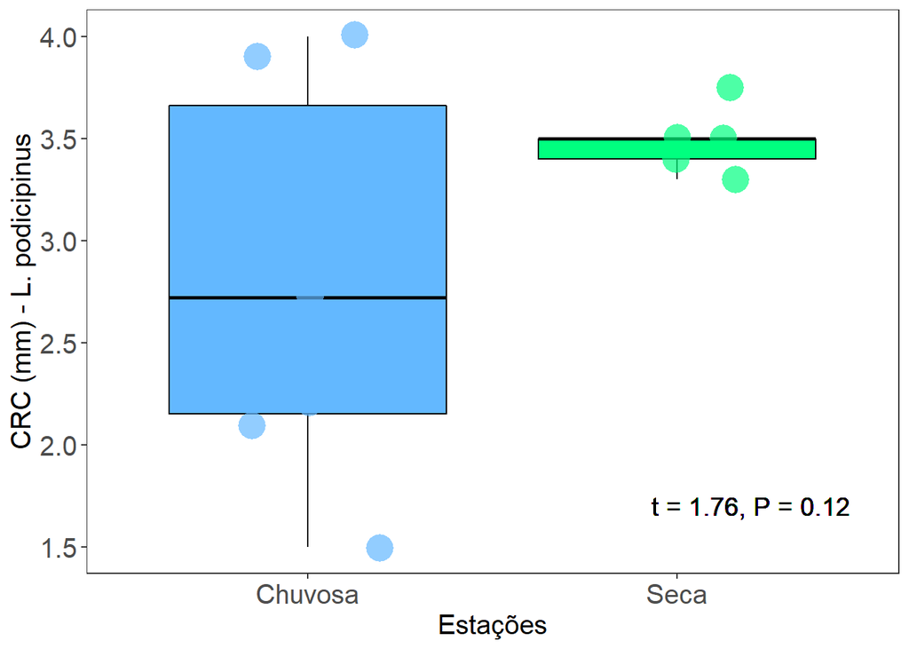

```r
library(ggplot2)
ggplot(data = CRC_LP_femea, aes(x= Estacao, y= CRC, color = Estacao)) +
  labs(x = "Estações", y = "CRC (mm) - L. podicipinus", size = 15) +
  geom_boxplot(fill=c("steelblue1", "springgreen1"), color="black", outlier.shape = NA) +
  geom_jitter(shape = 16, position=position_jitter(0.2), cex = 7, alpha = 0.7) +
  scale_color_manual(values = c("steelblue1", "springgreen1")) +
  geom_text(x = 2.2, y = 1.7, label = "t = 1.76, P = 0.12", color = "black", size = 5) +
  theme_bw() +
  theme(axis.text.y = element_text(size = 15), axis.text.x = element_text(size = 15)) +
  theme(axis.title.y = element_text(size = 15), axis.title.x = element_text(size = 15)) +
  theme(panel.grid.major = element_blank(), panel.grid.minor = element_blank()) +
  theme(legend.position = "none")
```

**Interpretação dos resultados**

Neste exemplo, não rejeitamos a hipótese nula e consideramos que as médias do CRC das fêmeas entre as estações seca e chuvosa são iguais (t = 1,76, P = 0,12). Os resultados mostram que as fêmeas de *L. podicipinus* coletadas na estação chuvosa não são maiores do que as fêmeas coletadas na estação seca.

# Teste T para amostras pareadas

## Backgorund da análise

O Teste T Pareado é uma estatística que usa dados medidos duas vezes na mesma unidade amostral, resultando em pares de observações para cada amostra (amostras pareadas). Ele determina se a diferença da média entre duas observações é zero.

> $$t = \frac{\bar{d}}{S_{\bar{d}}}$$

Onde:

- $\bar{d}$ = média da diferença das medidas pareadas. Observe que o teste não usa as medidas originais, e sim, a diferença para cada par,
- S<sub>$\bar{d}$</sub> = erro padrão da diferença das medidas pareadas.

#### Premissas do Teste t para amostras pareadas:

> - As unidades amostrais são selecionadas aleatoriamente;
> - Distribuição normal (gaussiana) dos valores da diferença para cada par;

#### Exemplo prático 1 - Teste T para amostras pareadas

##### Explicação dos dados

Neste exemplo avaliaremos a diferença na riqueza de espécies de artrópodes registradas em 27 localidades. Todas as localidades foram amostradas duas vezes. A primeira amostragem foi realizada com na localidade antes da pertubação e a segunda amostragem foi realizada após a localidade ter sofrido uma queimada.

**Pergunta:**

> A riqueza de espécies de artrópodes é prejudicada pelas queimadas?

**Predições**

> A riqueza de espécies de artrópodes será maior antes da queimada devido a extinção local das espécies.

**Variáveis**

- Variáveis preditoras
  - Dataframe com as localidades nas linhas e riqueza de espécies (variável preditora contínua) e estado (Pre-queimada ou Pós-queimada - variável categórica) da localidade nas colunas.

**Checklist**

- Verificar se o seu dataframe está com as unidades amostrais nas linhas e variáveis preditores nas colunas

### Análise

Calculo do Teste T com amostras pareadas

```r
## IMPORTANDO OS DADOS
#*************************
Pareado <- read.csv("teste_t_pareado.csv", header = T, sep = ";")
head(Pareado) # verificar se o dataframe foi lido corretamente
```

```
##   Areas Riqueza       Estado
## 1     1      92 Pre-Queimada
## 2     2      74 Pre-Queimada
## 3     3      96 Pre-Queimada
## 4     4      89 Pre-Queimada
## 5     5      76 Pre-Queimada
## 6     6      80 Pre-Queimada
```

```r
# TESTE T PAREADO
#*****************
# O uso do [] é para selecionar dentro do vetor/coluna *Riqueza* os 27 primeiros números [1:27] que representam as localidades antes da queimada e os últimos 27 números [28:54] que representam as mesmas localidades pós-queimada
t.test(Pareado$Riqueza[1:27], Pareado$Riqueza[28:54], paired = TRUE)
```

```
##
##  Paired t-test
##
## data:  Pareado$Riqueza[1:27] and Pareado$Riqueza[28:54]
## t = 7.5788, df = 26, p-value = 4.803e-08
## alternative hypothesis: true difference in means is not equal to 0
## 95 percent confidence interval:
##  32.47117 56.63994
## sample estimates:
## mean of the differences
##                44.55556
```

Visualizar os resultados em gráfico

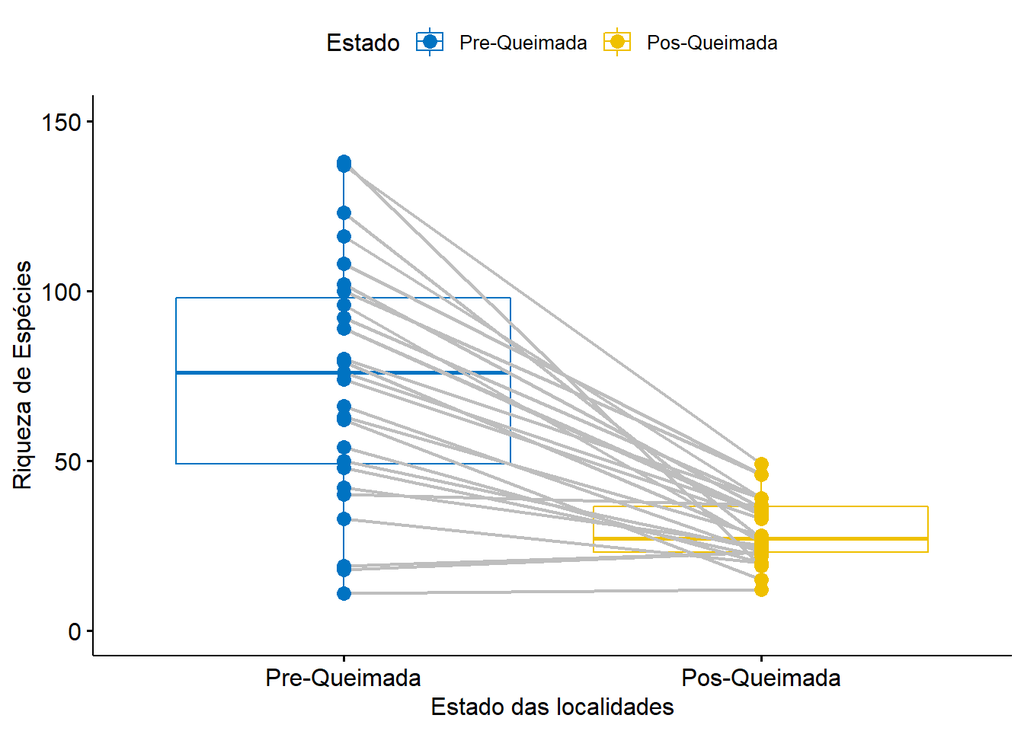

```r
library("ggpubr")
ggpaired(Pareado, x = "Estado", y = "Riqueza",
         color = "Estado", line.color = "gray", line.size = 0.8, palette = "jco", width = 0.8,
         point.size = 3, xlab = "Estado das localidades", ylab = "Riqueza de Espécies") +
  expand_limits(y=c(0,150))
```

**Interpretação dos resultados**

Neste exemplo, rejeitamos a hipótese nula que a riqueza de espécies de artrópodes é igual antes e depois da queimada (t = 7,57, P < 0,001). Os resultados mostram que as localidades após as queimadas apresentam em média 44,5 espécies de artrópodes a menos do que antes das queimadas.

# Correlação de Pearson

## Backgorund da análise

É um teste que mede a força relativa da relação linear entre duas variáveis contínuas (X e Y). Importante ressaltar que a análise de correlação não assume que a variável X influêncie a variável Y ou que exista uma relação de causa e efeito entre elas (Zar 2016). A análise é definida em termos da variância de X, a variância de Y, e a covariância de X e Y (i.e. como elas variam juntas).

> $$r = \frac{\sum{XY} - \frac{\sum{X} \sum{Y}}{n}}{\sqrt{\left(\sum{X^2} - \frac{\sum{X}^2}{n}\right)\left(\sum{Y^2} - \frac{\sum{Y}^2}{n}\right)}}$$

Onde:

- r = coeficiente de correlação que indica a força da relação entre as duas variáveis. Seu range de valores está entre -1 $\leq$ r $\geq$ 1. A correlação positiva indica que o aumento no valor de uma das variáveis é acompanhado pelo aumento no valor da outra variável. A correlação negativa indica que um aumento no valor de uma das variáveis é acompanhado pela diminuição no valor da outra variável. Se *r* é igual a zero, não existe correlação entre as variáveis (Figura 2).

#### Premissas da Correlação de Person:

> - As amostras devem ser independentes e pareadas (i.e. as duas variáveis devem ser medidas na mesma unidade amostral);
> - As unidades amostrais são selecionadas aleatoriamente;
> - A relação entre as variáveis tem que ser linear.

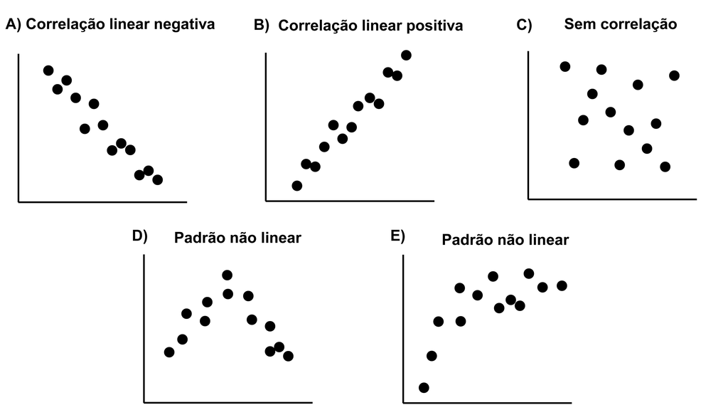

#### Exemplo prático 1 - Correlação de Pearson

##### Explicação dos dados

Neste exemplo avaliaremos a correlação entre a altura do tronco e o tamanho da raiz medidos em 35 indivíduos de uma espécie vegetal arbustiva.

**Pergunta:**

> Existe correlação entre a altura do tronco e o tamanho da raiz dos arbustos?

**Predições**

> A altura do tronco é positivamente correlacionado com o tamanho da raiz.

**Variáveis**

- Variáveis preditoras
  - Dataframe com os indivíduos (unidade amostral) nas linhas e altura do tronco e tamanho da raiz (duas variáveis tem que ser contínuas) como colunas.

**Checklist**

- Verificar se o seu dataframe está com as unidades amostrais nas linhas e variáveis preditores nas colunas

### Análise

Calculo do Teste de Correlação de Pearson

```r
## IMPORTANDO OS DADOS
#************************
correlacao_arbustos <- read.csv("Correlacao.csv", header = T, sep = ";")
head(correlacao_arbustos) # verificar se o dataframe foi lido corretamente
```

```
##   Tamanho_raiz Tamanho_tronco
## 1    10.177049       19.54383
## 2     6.622634       17.13558
## 3     7.773629       19.50681
## 4    11.055257       21.57085
## 5     4.487274       13.22763
## 6    11.190216       21.62902
```

```r
# Teste de Correlação de Pearson
#********************************
# Para outros testes de correlação como Kendall ou Spearman é só alterar na linha de comando a opção *method* e inserir o teste desejado.
cor.test(correlacao_arbustos$Tamanho_raiz, correlacao_arbustos$Tamanho_tronco, method = "pearson")
```

```
##
##  Pearson's product-moment correlation
##
## data:  correlacao_arbustos$Tamanho_raiz and correlacao_arbustos$Tamanho_tronco
## t = 11.49, df = 33, p-value = 4.474e-13
## alternative hypothesis: true correlation is not equal to 0
## 95 percent confidence interval:
##  0.7995083 0.9457816
## sample estimates:
##       cor
## 0.8944449
```

Visualizar os resultados em gráfico

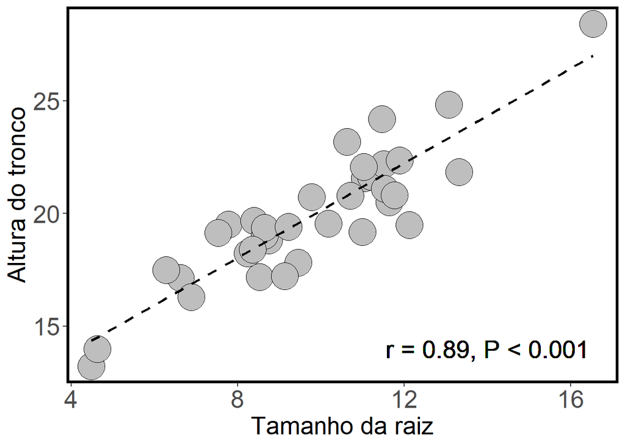

```r
library(ggplot2)
ggplot(data = correlacao_arbustos, aes(x= Tamanho_raiz, y= Tamanho_tronco)) +
  labs(x = "Tamanho da raiz", y = "Altura do tronco", size = 20) +
  geom_point(size = 10, shape = 21, fill = "gray") +
  geom_text(x = 14, y = 14, label = "r = 0.89, P < 0.001", color = "black", size = 7) +
  theme_bw() +
  theme(axis.title.y = element_text(size = 20), axis.title.x = element_text(size = 20)) +
  theme(axis.text.y = element_text(size = 20), axis.text.x = element_text(size = 20)) +
  theme(panel.grid.major = element_blank(), panel.grid.minor = element_blank(),
        panel.border = element_rect(colour = "black", fill=NA, size = 2)) +
  geom_smooth(method = lm, se = FALSE, color = "black", linetype="dashed")
```

**Interpretação dos resultados**

Neste exemplo, rejeitamos a hipótese nula que as variáveis não são correlacionadas (r = 0.89, P < 0,001). Os resultados mostram que o aumento na altura dos arbutos é acompanhado pelo aumento no tamanho da raiz.

# Regressão Simples

## Backgorund da análise

A regressão simples é usada para analisar a relação entre uma variável preditora (plotada no eixo-X) e uma variável resposta (plotada no eixo-Y). As duas variáveis devem ser contínuas. Diferente das correlações, a regressão assume uma relação de causa e efeito entre as variáveis. O valor da variável preditora (X) causa, direta ou indiretamente, o valor da variável resposta (Y). Assim, Y é uma função linear de X:

> $$Y = \beta_0 + \beta_{1}X_i + \epsilon_i$$

Onde:

- $\beta_0$ = intercepto que representa o valor da função quando X = 0,
- $\beta_{1}$ = inclinação (*slope*) que mede a mudança na variável Y para cada mudança de unidade da variável X.
- $\epsilon_{1}$ = erro aleatório referente a variável Y que não pode ser explicado pela variável X.

#### Premissas da Regressão Simples:

> - As amostras devem ser independentes;
> - As unidades amostrais são selecionadas aleatoriamente;
> - Distribuição normal (gaussiana) dos resíduos;
> - Homogeneidade da variância.

#### Exemplo prático 1 - Regressão simples

##### Explicação dos dados

Neste exemplo, avaliaremos a relação entre o gradiente de temperatura média anual (°C) e o tamanho médio do comprimento rostro-cloacal (CRC em mm) de populações de *Dendropsophus minutus* (Anura:Hylidae) amostradas em 109 localidades no Brasil (Boaratti & da Silva 2015).

**Pergunta:**

> Há relação entre o tamanho do CRC das populações e a temperatura das localidades onde os indivíduos ocorrem?

**Predições**

> O CRC das populações serão menores em localidades mais quentes do que em localidades mais frias de acordo com a Hipótese do balanço de calor.

**Variáveis**

- Variáveis preditoras
  - Dataframe com as populações (unidade amostral) nas linhas e CRC médio (mm) e temperatura média anual como colunas.

**Checklist**

- Verificar se o seu dataframe está com as unidades amostrais nas linhas e variáveis preditores nas colunas

### Análise

Calculo da regressão simples

```r
## IMPORTANDO DADOS
#********************
dados_regressao <- read.csv("regressoes.csv", header = T, sep = ";")
head(dados_regressao) # verificar se o dataframe foi lido corretamente
```

```
##      Municipio      CRC Temperatura Precipitacao
## 1     Acorizal 22.98816    24.13000       1228.2
## 2  Alpinopolis 22.91788    20.09417       1487.6
## 3 Alto_Paraiso 21.97629    21.86167       1812.4
## 4    Americana 23.32453    20.28333       1266.2
## 5      Apiacas 22.83651    25.47333       2154.0
## 6  Arianopolis 20.86989    20.12167       1269.2
```

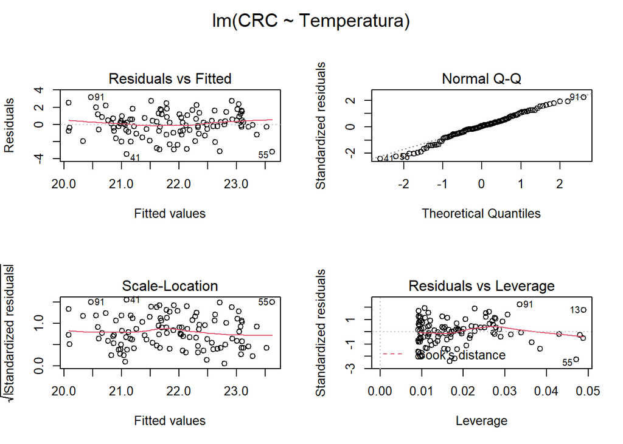

```r
# ANALISE DA REGRESSÃO
#************************
modelo_regressao <- lm(CRC ~ Temperatura, data = dados_regressao)

# PRIMEIRO VAMOS VERIFICAR A NORMALIDADE E HOMOGENEIDADE DAS VARIÂNCIAS
#***********************************************************************
# Os gráficos *Residuals vs Fitted*, *Scale-Location*, e *Residual vs Leverage* estão relacionados com a homogeneidade da variância. Nestes gráficos, esperamos ver os pontos dispersos no espaço sem padrões com formatos em *U* ou funil.
# O gráfico *Normal Q-Q* está relacionado com a distribuição normal dos resíduos. Neste gráfico, esperamos ver os pontos próximos a reta sem padrões com formatos em *U* ou *S*.
par(mfrow = c(2, 2), oma = c(0, 0, 2, 0))
plot(modelo_regressao)
```

```r
dev.off()
```

```r
# VERIFICANDO OS RESULTADOS DA REGRESSÃO
#****************************************
anova(modelo_regressao)
```

```
## Analysis of Variance Table
##
## Response: CRC
##              Df  Sum Sq Mean Sq F value    Pr(>F)
## Temperatura   1  80.931  80.931   38.92 9.011e-09 ***
## Residuals   107 222.500   2.079
## ---
## Signif. codes:  0 '***' 0.001 '**' 0.01 '*' 0.05 '.' 0.1 ' ' 1
```

```r
# ou
# esta função apresenta os resultados mais detalhados com a estimativa do intercepto, inclinação da reta (slope) e o coeficiente de determinação (R2) que indica a proporção da variação na variável Y que pode ser atribuída à variação na variável X.
summary(modelo_regressao)
```

```
##
## Call:
## lm(formula = CRC ~ Temperatura, data = dados_regressao)
##
## Residuals:
##     Min      1Q  Median      3Q     Max
## -3.4535 -0.7784  0.0888  0.9168  3.1868
##
## Coefficients:
##             Estimate Std. Error t value Pr(>|t|)
## (Intercept) 16.23467    0.91368  17.768  < 2e-16 ***
## Temperatura  0.26905    0.04313   6.239 9.01e-09 ***
## ---
## Signif. codes:  0 '***' 0.001 '**' 0.01 '*' 0.05 '.' 0.1 ' ' 1
##
## Residual standard error: 1.442 on 107 degrees of freedom
## Multiple R-squared:  0.2667, Adjusted R-squared:  0.2599
## F-statistic: 38.92 on 1 and 107 DF,  p-value: 9.011e-09
```

Visualizar os resultados em gráfico

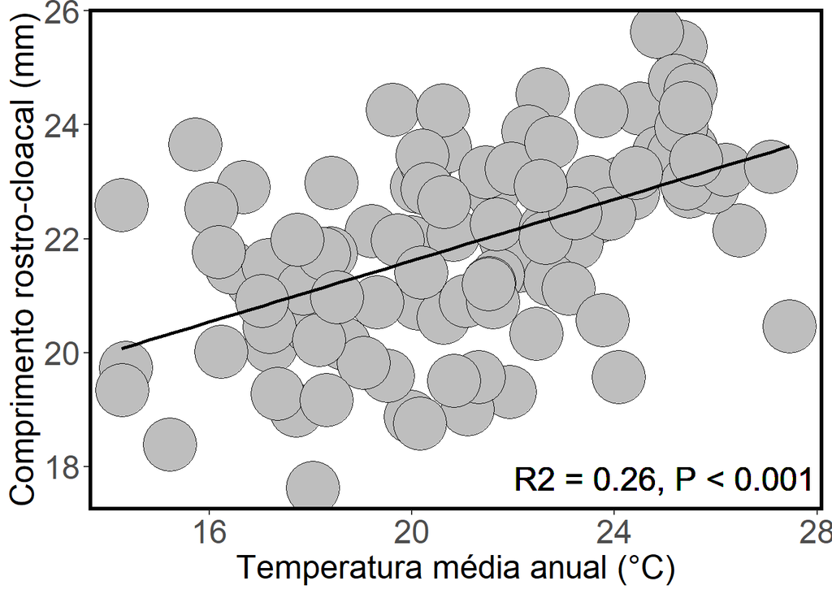

```r
library(ggplot2)
ggplot(data = dados_regressao, aes(x= Temperatura, y= CRC)) +
  labs(x = "Temperatura média anual (°C)", y = "Comprimento rostro-cloacal (mm)", size = 20) +
  geom_point(size = 15, shape = 21, fill = "gray") +
  geom_text(x = 25, y = 17.8, label = "R2 = 0.26, P < 0.001", color = "black", size = 7) +
  theme_bw() +
  theme(axis.title.y = element_text(size = 20), axis.title.x = element_text(size = 20)) +
  theme(axis.text.y = element_text(size = 20), axis.text.x = element_text(size = 20)) +
  theme(panel.grid.major = element_blank(), panel.grid.minor = element_blank(),
        panel.border = element_rect(colour = "black", fill=NA, size = 2)) +
  geom_smooth(method = lm, se = FALSE, color = "black")
```

**Interpretação dos resultados**

Neste exemplo, rejeitamos a hipótese nula que não existe relação entre o tamanho do CRC das populações de *D. minutus* e a temperatura da localidade onde elas ocorrem (F<sub>1,107</sub> = 38,92, P < 0,001). Os resultados mostram que o tamanho do CRC das populações tem uma relação positiva com a temperatura das localidades. Assim, populações de *D. minutus* em localidades mais quentes apresentam maior CRC do que as populações em localidades mais frias.

# Regressão Múltipla

## Backgorund da análise

A regressão múltipla é uma extensão da regressão simples. Ela é usada quando queremos determinar o valor da variável resposta (Y) com base nos valores de duas ou mais variáveis preditoras (X<sub>1</sub>, X<sub>2</sub>, X<sub>*n*</sub>).

> $$Y = \beta_0 + \beta_{1}X_1 + \beta_{n}X_n + \epsilon_i$$

Onde:

- $\beta_0$ = intercepto que representa o valor da função quando X = 0;
- $\beta_{n}$ = inclinação (*slope*) que mede a mudança na variável Y para cada mudança de unidade das variáveis X<sub>n</sub>;
- $\epsilon_{1}$ = erro aleatório referente a variável Y que não pode ser explicado pelas variáveis preditoras.

#### Premissas da Regressão Múltipla:

> - As amostras devem ser independentes;
> - As unidades amostrais são selecionadas aleatoriamente;
> - Distribuição normal (gaussiana) dos resíduos;
> - Homogeneidade da variância.

#### Exemplo prático 1 - Regressão múltipla

##### Explicação dos dados

Utilizaremos o mesmo exemplo da regressão simples. Contudo, além do gradiente de temperatura média anual (°C) incluiremos o gradiente de precipitação anual (mm) como outra variável preditora do tamanho médio do comprimento rostro-cloacal (CRC em mm) de populações de *Dendropsophus minutus* (Anura:Hylidae) amostradas em 109 localidades no Brasil (Boaratti & da Silva 2015).

**Pergunta:**

> O tamanho do CRC das populações de *D. minutus* é influênciado pela temperatura e precipitação das localidades onde os indivíduos ocorrem?

**Predições**

> O CRC das populações serão menores em localidades com clima quente e chuvoso do que em localidades com clima frio e seco.

**Variáveis**

- Variáveis preditoras
  - Dataframe com as populações (unidade amostral) nas linhas e CRC médio (mm) e temperatura e precipitação como colunas.

**Checklist**

- Verificar se o seu dataframe está com as unidades amostrais nas linhas e variáveis preditores nas colunas

### Análise

Cálculo da regressão múltipla

```r
## IMPORTANDO DADOS
#********************
dados_regressao_mul <- read.csv("regressoes.csv", header = T, sep = ";")
head(dados_regressao_mul) # verificar se o dataframe foi lido corretamente
```

```
##      Municipio      CRC Temperatura Precipitacao
## 1     Acorizal 22.98816    24.13000       1228.2
## 2  Alpinopolis 22.91788    20.09417       1487.6
## 3 Alto_Paraiso 21.97629    21.86167       1812.4
## 4    Americana 23.32453    20.28333       1266.2
## 5      Apiacas 22.83651    25.47333       2154.0
## 6  Arianopolis 20.86989    20.12167       1269.2
```

```r
# ANALISE DA REGRESSÃO
#************************
modelo_regressao_mul <- lm(CRC ~ Temperatura + Precipitacao, data = dados_regressao_mul)

# MULTICOLINEARIDADE
#********************
# Multicolinearidade ocorre quando as variáveis preditoras são correlacionadas. Essa correlação é um problema porque as variáveis preditores deveriam ser independentes. O Fator de Inflação da Variância (VIF) é um teste que identifica a correlação entre as variáveis e mostra a força dessa correlação. Alguns autores consideram valores de VIF acima de 10 como fortemente correlacionadas, outros mais conservadores consideram o valor de 3.
library(car)
vif(modelo_regressao_mul)
```

```
##  Temperatura Precipitacao
##     1.041265     1.041265
```

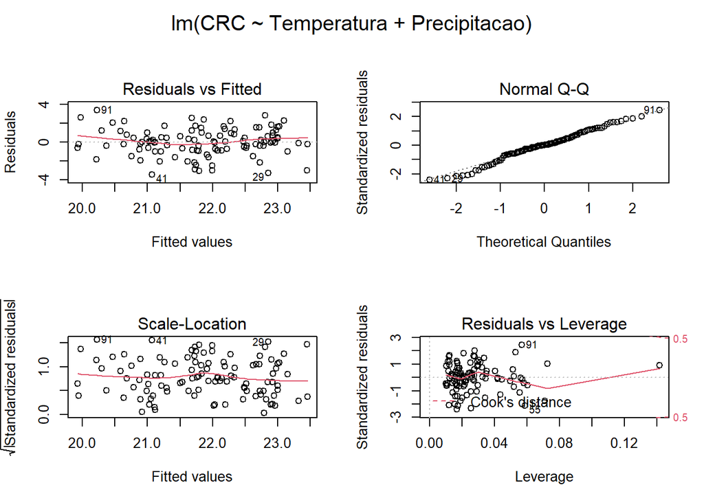

```r
# VERIFICANDO A NORMALIDADE E HOMOGENEIDADE DAS VARIÂNCIAS
#***********************************************************************
# Os gráficos *Residuals vs Fitted*, *Scale-Location*, e *Residual vs Leverage* estão relacionados com a homogeneidade da variância. Nestes gráficos, esperamos ver os pontos dispersos no espaço sem padrões em forma de *U* ou funil.
# O gráfico *Normal Q-Q* está relacionado com a distribuição normal dos resíduos. Neste gráfico, esperamos ver os pontos próximos a reta sem padrões em forma de *U* ou *S*.
par(mfrow = c(2, 2), oma = c(0, 0, 2, 0))
plot(modelo_regressao_mul)
```

```r
dev.off()
```

```r
# VERIFICANDO OS RESULTADOS DA REGRESSÃO
#****************************************
anova(modelo_regressao_mul)
```

```
## Analysis of Variance Table
##
## Response: CRC
##               Df  Sum Sq Mean Sq F value   Pr(>F)
## Temperatura    1  80.931  80.931 39.0028 8.94e-09 ***
## Precipitacao   1   2.549   2.549  1.2283   0.2702
## Residuals    106 219.951   2.075
## ---
## Signif. codes:  0 '***' 0.001 '**' 0.01 '*' 0.05 '.' 0.1 ' ' 1
```

```r
# ou
summary(modelo_regressao_mul)
```

```
##
## Call:
## lm(formula = CRC ~ Temperatura + Precipitacao, data = dados_regressao_mul)
##
## Residuals:
##     Min      1Q  Median      3Q     Max
## -3.4351 -0.8026  0.0140  0.9420  3.4300
##
## Coefficients:
##                Estimate Std. Error t value Pr(>|t|)
## (Intercept)  16.7162571  1.0108674  16.537  < 2e-16 ***
## Temperatura   0.2787445  0.0439601   6.341 5.71e-09 ***
## Precipitacao -0.0004270  0.0003852  -1.108     0.27
## ---
## Signif. codes:  0 '***' 0.001 '**' 0.01 '*' 0.05 '.' 0.1 ' ' 1
##
## Residual standard error: 1.44 on 106 degrees of freedom
## Multiple R-squared:  0.2751, Adjusted R-squared:  0.2614
## F-statistic: 20.12 on 2 and 106 DF,  p-value: 3.927e-08
```

Percebam que a temperatura tem uma relação significativa com o tamanho do CRC das populações (P < 0.001), enquanto que a precipitação não apresenta relação com o CRC (P = 0.27). Neste caso, é interessante saber se um modelo mais simples (e.g. contendo apenas temperatura) explicaria a distribuição tão bem ou melhor do que este modelo mais complexo considerando dois parâmetros (temperatura e precipitação).

Para isso, podemos utilizar a *LIKELIHOOD RATIO TEST (LRT)* para comparar modelos. A LRT compara dois modelos aninhados, testando se os parâmetros do modelo mais complexo diferem significativamente do modelo mais simples.Em outras palavras, ele testa se há necessidade de se incluir um parâmetro extra no modelo para explicar os dados.

```r
## CRIANDO OS MODELOS ANINHADOS
#********************************
modelo_regressao_mul <- lm(CRC ~ Temperatura + Precipitacao, data = dados_regressao_mul)
modelo_regressao <- lm(CRC ~ Temperatura, data = dados_regressao_mul)

# LIKELIHHOD RATIO TEST (LRT)
#*******************************
# A hipótese nula é que o modelo mais simples é melhor
# Valores de p < 0.05 rejeita a hipótese nula e o modelo mais complexo é o melhor
# Valores de p > 0.05 não rejeita a hipótese nula e o modelo mais simples é o melhor
library(lmtest)
lrtest(modelo_regressao_mul, modelo_regressao)
```

```
## Likelihood ratio test
##
## Model 1: CRC ~ Temperatura + Precipitacao
## Model 2: CRC ~ Temperatura
##   #Df  LogLik Df  Chisq Pr(>Chisq)
## 1   4 -192.93
## 2   3 -193.55 -1 1.2558     0.2624
```

```r
# COMPARANDO COM O MODELO SOMENTE COM O INTERCEPTO
#************************************************
# criando um modelo sem parâmetros, só o intercepto
modelo_intercepto <- lm(CRC ~ 1, data = dados_regressao_mul)
lrtest(modelo_regressao, modelo_intercepto)
```

```
## Likelihood ratio test
##
## Model 1: CRC ~ Temperatura
## Model 2: CRC ~ 1
##   #Df  LogLik Df  Chisq Pr(>Chisq)
## 1   3 -193.55
## 2   2 -210.46 -1 33.815  6.061e-09 ***
## ---
## Signif. codes:  0 '***' 0.001 '**' 0.01 '*' 0.05 '.' 0.1 ' ' 1
```

**Interpretação dos resultados**

Neste exemplo, a precipitação não está associada com a variação no tamanho do CRC das populações de *D. minutus*. Por outro lado, temperatura explicou 26% da variação do tamanho do CRC das populações.

# Análises de Variância (ANOVA)

## Backgorund da análise

Anova refere-se a uma variedade de delineamentos experimentais nos quais a variável preditora é categórica e a variável resposta é contínua (Gotelli & Ellison 2013). Exemplos desses delineamentos experimentais são: Anova de um fator, Anova de dois fatores, Anova em blocos aleatorizados, Anova de medidas repetidas e Anova *split-splot*. De forma geral, a Anova é um teste estatístico usado para comparar a média entre grupos amostrados independentementes. Para isso, o teste leva em conta, além das médias dos grupos, a variação dos dados dentro e entre os grupos. Neste capítulo, iremos demonstrar as linhas de comandos para alguns dos principais delineamentos experimentais.

#### Premissas da Anova:

> - As amostras devem ser independentes;
> - As unidades amostrais são selecionadas aleatoriamente;
> - Distribuição normal (gaussiana) dos resíduos;
> - Homogeneidade da variância.